# week_04_netl_hclust

### NETL Cyclone data

This notebook builds off the NETL Cyclone KMeans example. We will apply hierarchical clustering to the NETL Cyclone data.

## Import Modules

```python
import numpy as np
import pandas as pd
import matplotlib.pyplot as plt

import seaborn as sns
```

## Read data

```python
netl = pd.read_csv('../../from_2100/netl/cyclone_model_runs.csv')
```

```python
netl.info()
```

```
<class 'pandas.core.frame.DataFrame'>
RangeIndex: 96 entries, 0 to 95
Data columns (total 8 columns):
 #   Column    Non-Null Count  Dtype
---  ------    --------------  -----
 0   model     96 non-null     int64
 1   r_barrel  96 non-null     float64
 2   r_vortex  96 non-null     float64
 3   h_vortex  96 non-null     float64
 4   w_inlet   96 non-null     float64
 5   h_inlet   96 non-null     float64
 6   mass      96 non-null     float64
 7   pressure  96 non-null     float64
dtypes: float64(7), int64(1)
memory usage: 6.1 KB
```

```python
netl.dtypes
```

```
model         int64
r_barrel    float64
r_vortex    float64
h_vortex    float64
w_inlet     float64
h_inlet     float64
mass        float64
pressure    float64
dtype: object
```

```python
netl.nunique()
```

```
model       96
r_barrel    96
r_vortex    96
h_vortex    96
w_inlet     96
h_inlet     96
mass        93
pressure    96
dtype: int64
```

```python
netl.isna().sum()
```

```
model       0
r_barrel    0
r_vortex    0
h_vortex    0
w_inlet     0
h_inlet     0
mass        0
pressure    0
dtype: int64
```

Separate the INPUTS from the OUTPUTS.

```python
input_df = netl.drop(columns=['model', 'mass', 'pressure']).copy()
```

```python
output_df = netl.loc[ :, ['mass', 'pressure'] ].copy()
```

```python
input_df.columns
```

```
Index(['r_barrel', 'r_vortex', 'h_vortex', 'w_inlet', 'h_inlet'], dtype='object')
```

```python
output_df.columns
```

```
Index(['mass', 'pressure'], dtype='object')
```

Explore the inputs via a pairs plot.

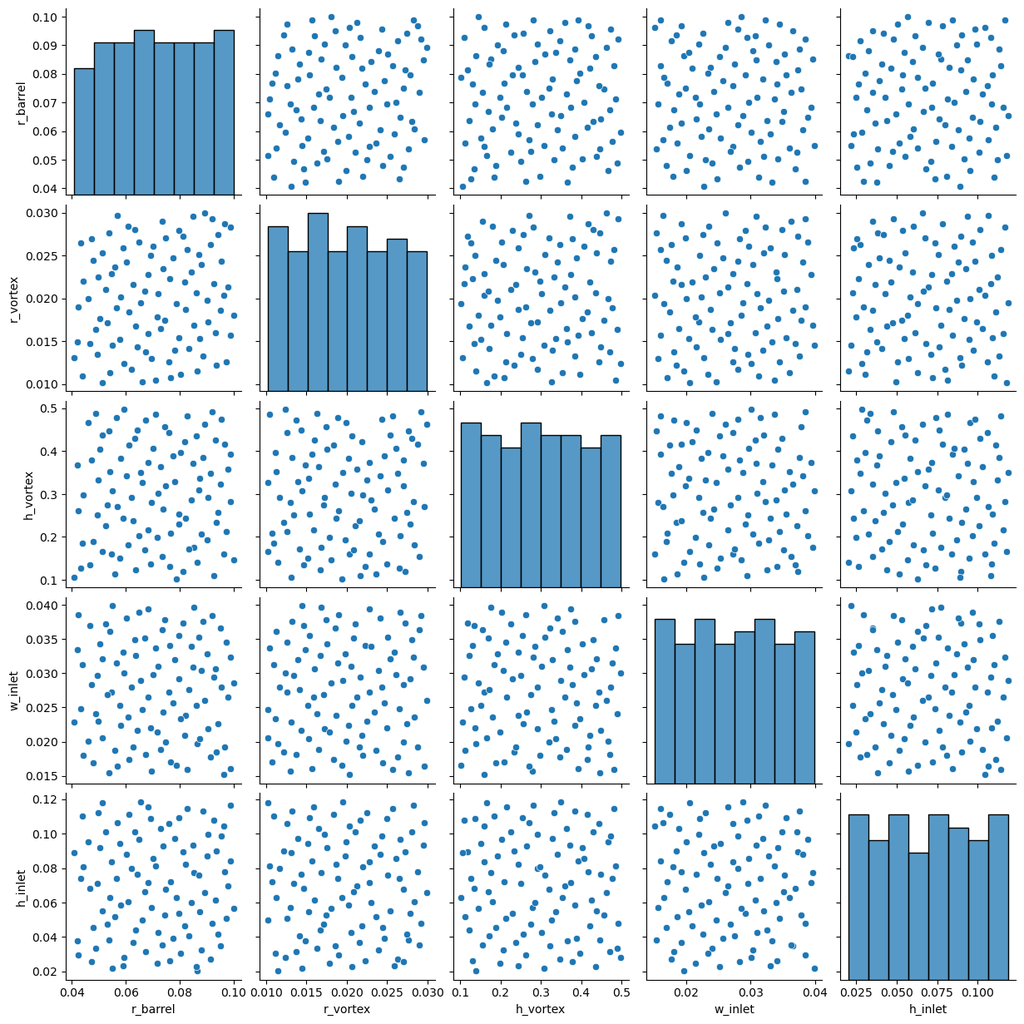

```python
sns.pairplot(data = input_df)

plt.show()
```

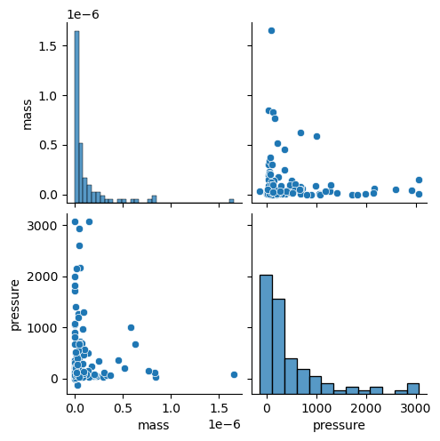

```python
sns.pairplot(data = output_df)

plt.show()
```

From a clustering perspective, can we find patterns based on the OUTPUTS and then associate those patterns to the INPUTS? This lets us explore the INPUT to OUTPUT relationship **before** we fit the models to PREDICT the output behavior!

Let's check the RELATIONSHIP between the OUTPUTS.

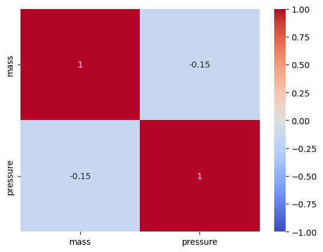

```python
fig, ax = plt.subplots()

sns.heatmap(data = output_df.corr(numeric_only=True),
            vmin=-1, vmax=1, center=0,
            cmap='coolwarm',
            annot=True,
            ax=ax)

plt.show()
```

Let's look at the scatter plot directly.

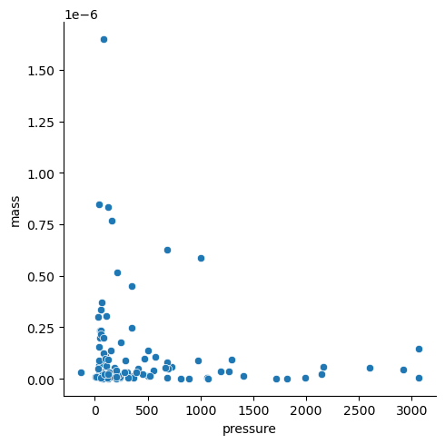

```python
sns.relplot(data = output_df, x='pressure', y='mass')

plt.show()
```

```python
output_df.describe().round(3)
```

|  | mass | pressure |
| --- | --- | --- |
| count | 96.0 | 96.000 |
| mean | 0.0 | 510.556 |
| std | 0.0 | 707.555 |
| min | 0.0 | -133.910 |
| 25% | 0.0 | 83.482 |
| 50% | 0.0 | 202.609 |
| 75% | 0.0 | 671.497 |
| max | 0.0 | 3068.301 |

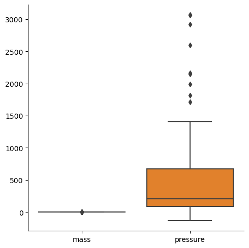

```python
sns.catplot(data = output_df, kind='box')

plt.show()
```

```python
output_df.skew()
```

[output not shown]

## Cluster the outputs

We clearly need to standardize the outputs BEFORE we apply clustering. The two have orders of magnitudes differences and so `mass` will NOT be accounted for at all in any distance calculation!!!! We must remove the magnitude and scale effects!!!

We must decide if we should remove the skew before applying clustering!

Let's try multiple approaches to see the influence of the SKEW on the clustering results!

### PREPROCESS - standardize only

```python
from sklearn.preprocessing import StandardScaler
```

```python
from sklearn.pipeline import Pipeline
```

```python
stan_wflow = Pipeline( steps=[('std_scale', StandardScaler())])
```

```python
output_stan_fit = stan_wflow.fit( output_df )
```

```python
Y = output_stan_fit.transform( output_df )
```

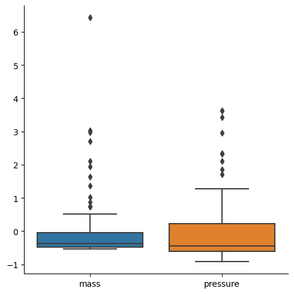

```python
sns.catplot(data = pd.DataFrame(Y, columns=output_df.columns), kind='box')

plt.show()
```

```python
pd.DataFrame(Y, columns=output_df.columns).skew()
```

```
mass        3.817507
pressure    2.158341
dtype: float64
```

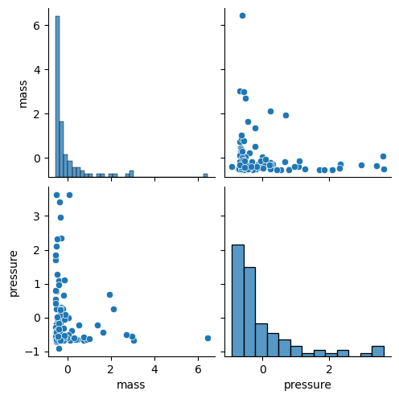

```python
sns.pairplot(data = pd.DataFrame(Y, columns=output_df.columns))

plt.show()
```

```python
pd.DataFrame(Y, columns=output_df.columns).corr()
```

|  | mass | pressure |
| --- | --- | --- |
| mass | 1.000000 | -0.152523 |
| pressure | -0.152523 | 1.000000 |

### KMeans with the standardized variables

```python
from sklearn.cluster import KMeans
```

Let's begin with 2 clusters just to see what happens!

```python
clusters_2 = KMeans(n_clusters=2, random_state=121, n_init=25, max_iter=500).fit_predict( Y )
```

```python
np.unique( clusters_2 )
```

```
array([0, 1])
```

Visualize the cluster results.

```python
output_df_copy = output_df.copy()
```

```python
output_df_copy['k2'] = pd.Series( clusters_2, index=output_df_copy.index).astype('category')
```

```python
output_df_copy.info()
```

```
<class 'pandas.core.frame.DataFrame'>
RangeIndex: 96 entries, 0 to 95
Data columns (total 3 columns):
 #   Column    Non-Null Count  Dtype
---  ------    --------------  -----
 0   mass      96 non-null     float64
 1   pressure  96 non-null     float64
 2   k2        96 non-null     category
dtypes: category(1), float64(2)
memory usage: 1.8 KB
```

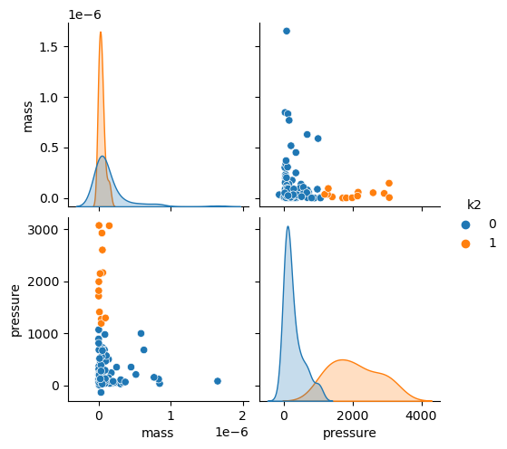

```python
sns.pairplot(data = output_df_copy, hue='k2', diag_kws={'common_norm': False})

plt.show()
```

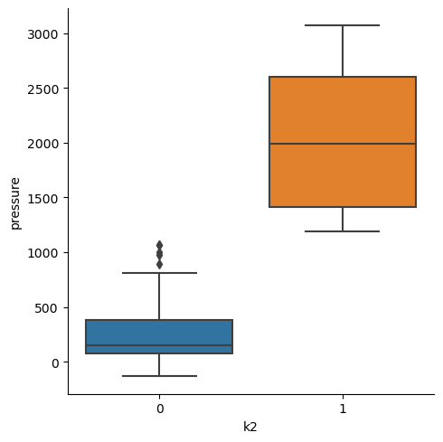

```python
sns.catplot(data = output_df_copy, x='k2', y='pressure', kind='box')

plt.show()
```

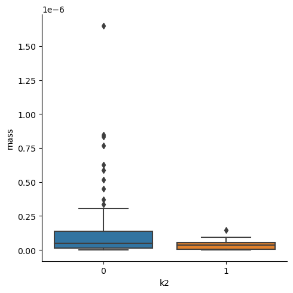

```python
sns.catplot(data = output_df_copy, x='k2', y='mass', kind='box')

plt.show()
```

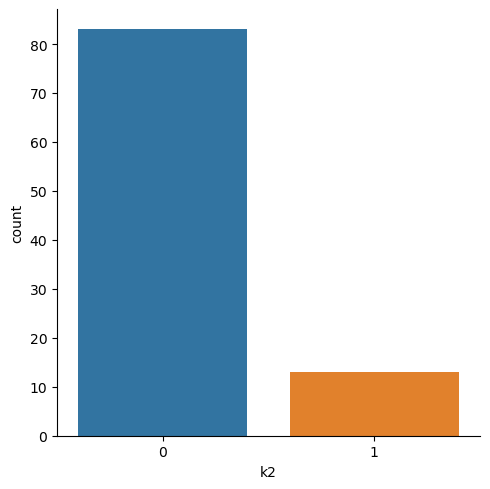

```python
sns.catplot(data = output_df_copy, x='k2', kind='count')

plt.show()
```

### PREPROCESS - removing skew

We discussed multiple ways to remove skew last week. But we will only consider one for this example.

```python
from sklearn.preprocessing import QuantileTransformer
```

```python
qt_wflow = Pipeline( steps=[('std_scale', StandardScaler()),
                            ('qt', QuantileTransformer(output_distribution='normal')),
                            ('std_qt', StandardScaler())] )
```

```python
output_qt_fit = qt_wflow.fit( output_df )
```

```python
Y_qt = output_qt_fit.transform( output_df )
```

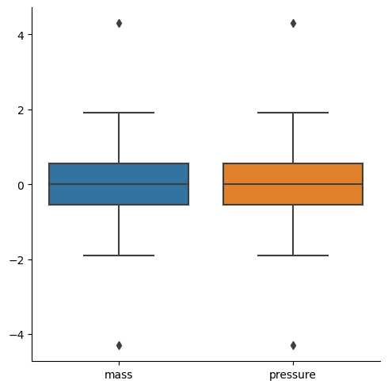

```python
sns.catplot(data = pd.DataFrame(Y_qt, columns=output_df.columns), kind='box')

plt.show()
```

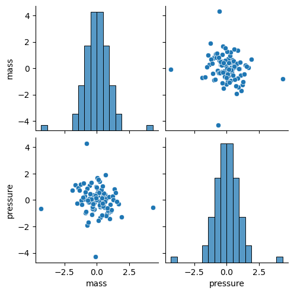

```python
sns.pairplot(data = pd.DataFrame(Y_qt, columns=output_df.columns))

plt.show()
```

```python
pd.DataFrame(Y_qt, columns=output_df.columns).corr()
```

|  | mass | pressure |
| --- | --- | --- |
| mass | 1.000000 | -0.158435 |
| pressure | -0.158435 | 1.000000 |

### KMeans with the QT variables

```python
k2_qt = KMeans(n_clusters=2, random_state=121, n_init=25, max_iter=500).fit_predict( Y_qt )
```

```python
output_qt_df = pd.DataFrame(Y_qt, columns=output_df.columns)
```

```python
output_qt_df['k2_qt'] = pd.Series( k2_qt, index=output_qt_df.index).astype('category')
```

```python
output_qt_df.info()
```

```
<class 'pandas.core.frame.DataFrame'>
RangeIndex: 96 entries, 0 to 95
Data columns (total 3 columns):
 #   Column    Non-Null Count  Dtype
---  ------    --------------  -----
 0   mass      96 non-null     float64
 1   pressure  96 non-null     float64
 2   k2_qt     96 non-null     category
dtypes: category(1), float64(2)
memory usage: 1.8 KB
```

```python
output_qt_df.k2_qt.value_counts()
```

```
k2_qt
0    54
1    42
Name: count, dtype: int64
```

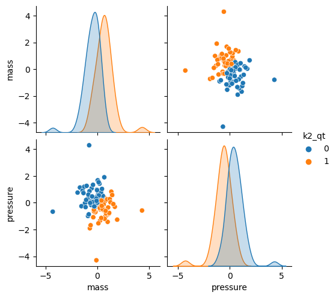

```python
sns.pairplot(data = output_qt_df, hue='k2_qt', diag_kws={'common_norm': False})

plt.show()
```

Let's examine the cluster results based on the TRANSFORMED variables relative to the ORIGINAL variables!

```python
output_df_copy.info()
```

```
<class 'pandas.core.frame.DataFrame'>
RangeIndex: 96 entries, 0 to 95
Data columns (total 3 columns):
 #   Column    Non-Null Count  Dtype
---  ------    --------------  -----
 0   mass      96 non-null     float64
 1   pressure  96 non-null     float64
 2   k2        96 non-null     category
dtypes: category(1), float64(2)
memory usage: 1.8 KB
```

```python
output_df_copy['k2_qt'] = pd.Series( k2_qt, index=output_df_copy.index).astype('category')
```

```python
output_df_copy.info()
```

```
<class 'pandas.core.frame.DataFrame'>
RangeIndex: 96 entries, 0 to 95
Data columns (total 4 columns):
 #   Column    Non-Null Count  Dtype
---  ------    --------------  -----
 0   mass      96 non-null     float64
 1   pressure  96 non-null     float64
 2   k2        96 non-null     category
 3   k2_qt     96 non-null     category
dtypes: category(2), float64(2)
memory usage: 2.0 KB
```

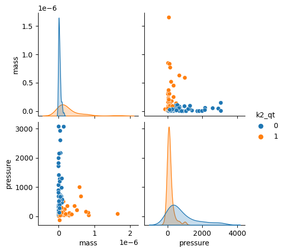

```python
sns.pairplot(data = output_df_copy, hue='k2_qt', diag_kws={'common_norm': False})

plt.show()
```

### Relate the cluster results to the inputs

Can we find any patterns associated within the inputs based on these cluster results?

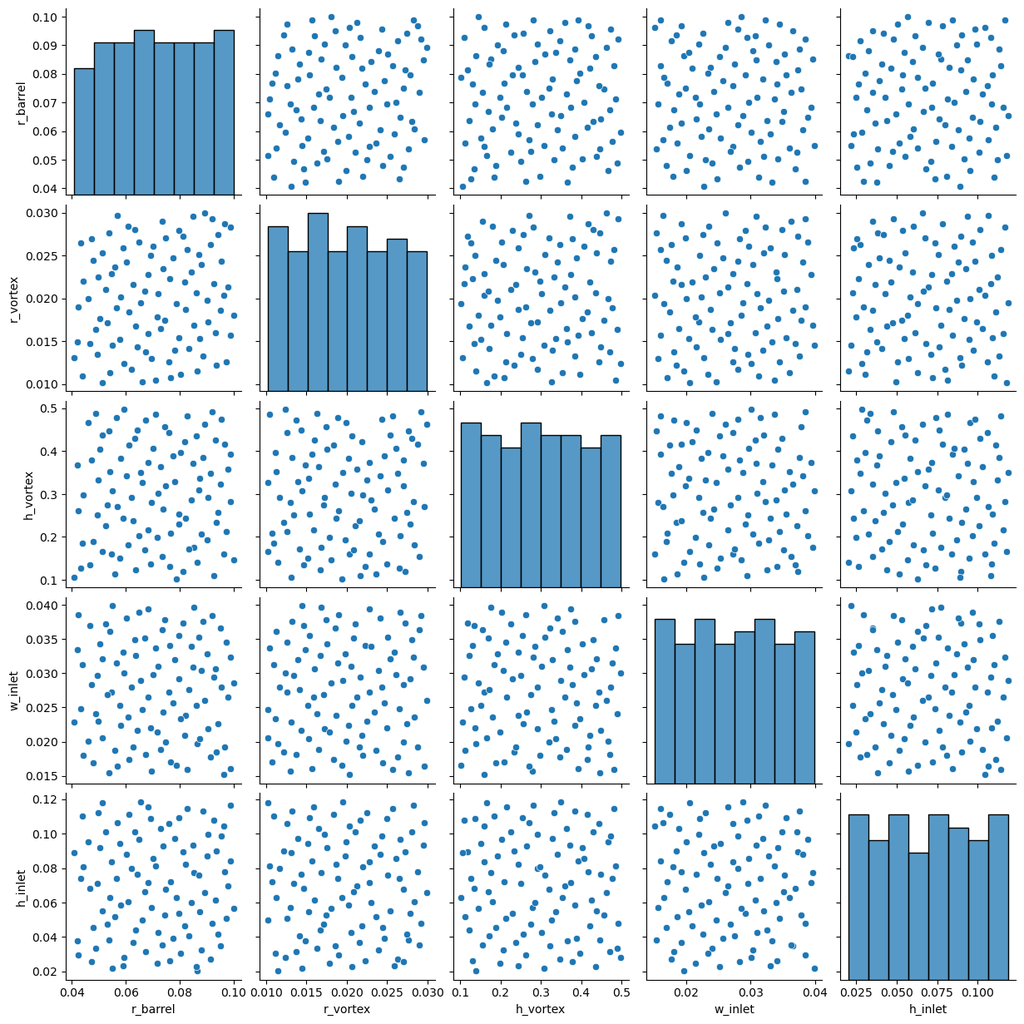

```python
sns.pairplot(data = input_df)

plt.show()
```

```python
input_df_copy = input_df.copy()
```

```python
input_df_copy['k2_qt'] = pd.Series( k2_qt, index=input_df_copy.index).astype('category')
```

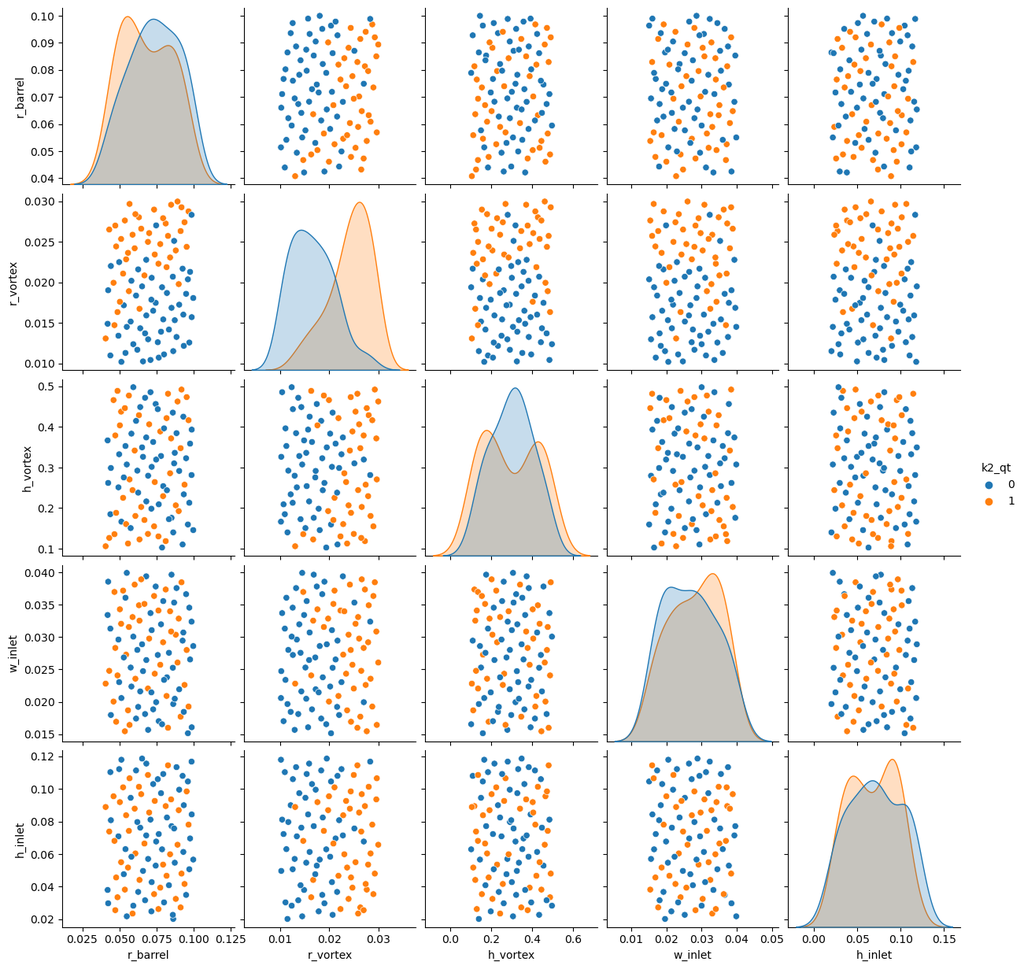

```python
sns.pairplot(data = input_df_copy, hue='k2_qt', diag_kws={'common_norm': False})

plt.show()
```

```python
input_lf = input_df_copy.reset_index().rename(columns={'index': 'rowid'}).melt(id_vars=['rowid', 'k2_qt'], ignore_index=True)
```

```python
input_lf.info()
```

```
<class 'pandas.core.frame.DataFrame'>
RangeIndex: 480 entries, 0 to 479
Data columns (total 4 columns):
 #   Column    Non-Null Count  Dtype
---  ------    --------------  -----
 0   rowid     480 non-null    int64
 1   k2_qt     480 non-null    category
 2   variable  480 non-null    object
 3   value     480 non-null    float64
dtypes: category(1), float64(1), int64(1), object(1)
memory usage: 11.9+ KB
```

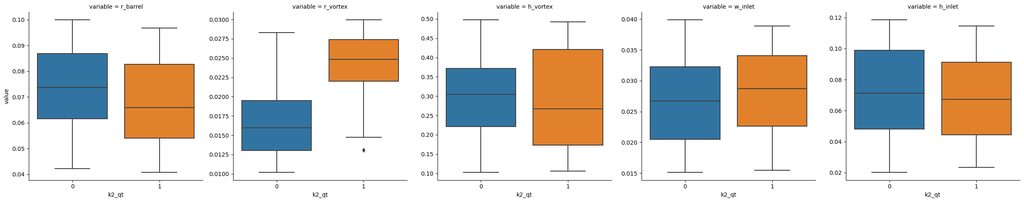

```python
sns.catplot(data = input_lf, x='k2_qt', y='value', col='variable', kind='box',
            sharey=False)

plt.show()
```

We have learned through CLUSTERING that the HIGHER values of `r_vortex` are associated with the CLUSTER that has LOWER VALUES of `pressure`!

```python
netl_copy = netl.copy()
```

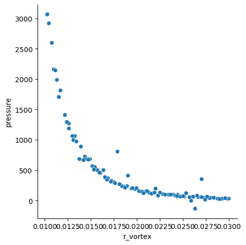

```python
sns.relplot(data = netl_copy, x='r_vortex', y='pressure')

plt.show()
```

```python
netl_copy['k2_qt'] = pd.Series(k2_qt, index=netl_copy.index).astype('category')
```

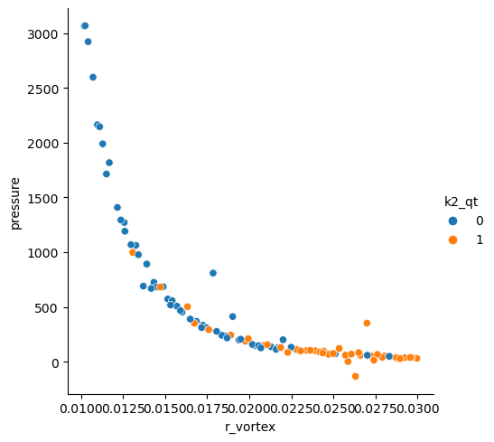

```python
sns.relplot(data = netl_copy, x='r_vortex', y='pressure', hue='k2_qt')

plt.show()
```

## Hierarchical clustering

We will use the QT output variables rather than the original or standardized-only variables.

```python
from scipy.cluster import hierarchy
```

### Ward linkage

```python
hclust_ward = hierarchy.ward( Y_qt )
```

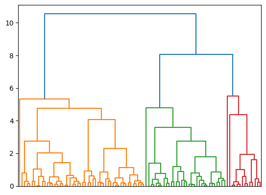

```python
fig = plt.figure()

dn = hierarchy.dendrogram( hclust_ward, no_labels=True )

plt.show()
```

```python
ward_cut_3 = hierarchy.cut_tree( hclust_ward, n_clusters=3 )
```

```python
ward_cut_3.shape
```

```
(96, 1)
```

```python
ward_cut_3.ravel().shape
```

```
(96,)
```

```python
output_qt_df
```

|  | mass | pressure | k2_qt |
| --- | --- | --- | --- |
| 0 | 0.635469 | 0.421077 | 1 |
| 1 | -0.650234 | -0.142493 | 0 |
| 2 | -0.471563 | 0.232059 | 0 |
| 3 | 0.727398 | 0.120401 | 1 |
| 4 | -0.098400 | -4.298500 | 1 |
| ... | ... | ... | ... |
| 91 | -0.120406 | 0.324442 | 0 |
| 92 | -0.510599 | 0.471555 | 0 |
| 93 | -0.076463 | 0.142493 | 0 |
| 94 | 0.098391 | -1.536148 | 1 |
| 95 | -0.301016 | -0.277816 | 0 |

96 rows × 3 columns

```python
output_qt_df['hclust_ward_3'] = pd.Series( ward_cut_3.ravel(), index=output_qt_df.index).astype('category')
```

```python
output_qt_df.info()
```

```
<class 'pandas.core.frame.DataFrame'>
RangeIndex: 96 entries, 0 to 95
Data columns (total 4 columns):
 #   Column         Non-Null Count  Dtype
---  ------         --------------  -----
 0   mass           96 non-null     float64
 1   pressure       96 non-null     float64
 2   k2_qt          96 non-null     category
 3   hclust_ward_3  96 non-null     category
dtypes: category(2), float64(2)
memory usage: 2.0 KB
```

```python
output_qt_df.hclust_ward_3.value_counts()
```

```
hclust_ward_3
1    50
0    32
2    14
Name: count, dtype: int64
```

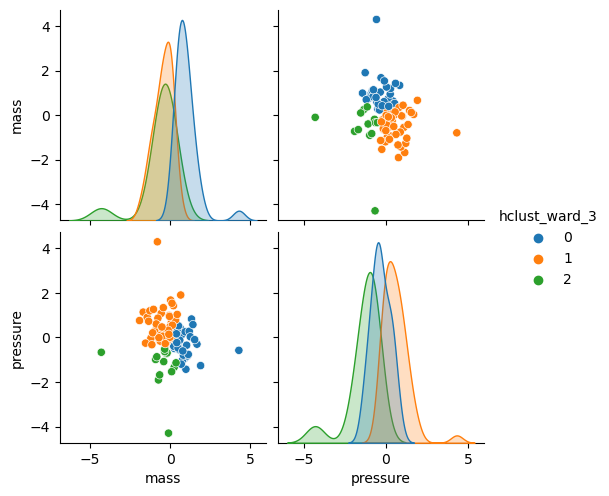

```python
sns.pairplot(data = output_qt_df, hue='hclust_ward_3', diag_kws={'common_norm': False})

plt.show()
```

### Single linkage

```python
hclust_single = hierarchy.single( Y_qt )
```

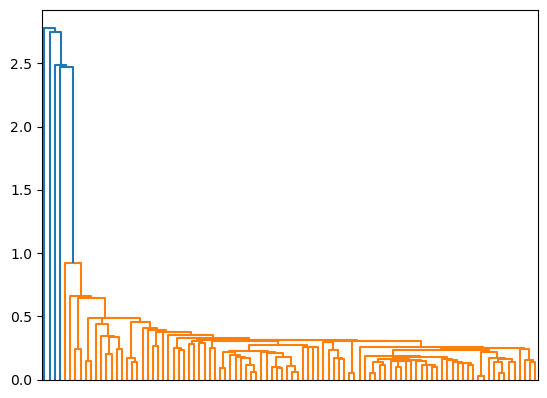

```python
fig = plt.figure()

dn = hierarchy.dendrogram( hclust_single, no_labels=True )

plt.show()
```

```python
single_cut_h1 = hierarchy.cut_tree( hclust_single, height=1)
```

```python
np.unique( single_cut_h1.ravel() )
```

```
array([0, 1, 2, 3, 4])
```

```python
single_cut_2 = hierarchy.cut_tree( hclust_single, n_clusters=2)
```

```python
np.unique( single_cut_2.ravel() )
```

```
array([0, 1])
```

```python
output_qt_df['hclust_single_2'] = pd.Series( single_cut_2.ravel(), index=output_qt_df.index).astype('category')
```

```python
output_qt_df.info()
```

```
<class 'pandas.core.frame.DataFrame'>
RangeIndex: 96 entries, 0 to 95
Data columns (total 5 columns):
 #   Column           Non-Null Count  Dtype
---  ------           --------------  -----
 0   mass             96 non-null     float64
 1   pressure         96 non-null     float64
 2   k2_qt            96 non-null     category
 3   hclust_ward_3    96 non-null     category
 4   hclust_single_2  96 non-null     category
dtypes: category(3), float64(2)
memory usage: 2.2 KB
```

```python
output_qt_df.hclust_single_2.value_counts()
```

```
hclust_single_2
0    95
1     1
Name: count, dtype: int64
```

```python
output_qt_df['hclust_single_h1'] = pd.Series( single_cut_h1.ravel(), index=output_qt_df.index).astype('category')
```

```python
output_qt_df.hclust_single_h1.value_counts()
```

```
hclust_single_h1
0    92
1     1
2     1
3     1
4     1
Name: count, dtype: int64
```

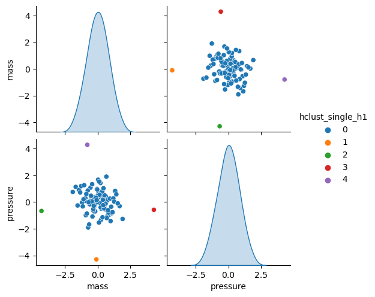

```python
sns.pairplot(data = output_qt_df, hue='hclust_single_h1', diag_kws={'common_norm': False})

plt.show()
```

```python
output_df_copy['hclust_single_h1'] = pd.Series( single_cut_h1.ravel(), index=output_df_copy.index).astype('category')
```

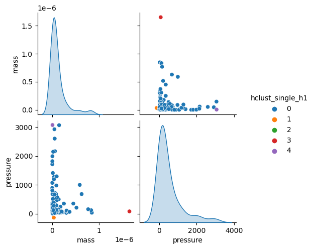

```python
sns.pairplot(data = output_df_copy, hue='hclust_single_h1', diag_kws={'common_norm': False})

plt.show()
```

```python
netl_copy['hclust_single_h1'] = pd.Series( single_cut_h1.ravel(), index=netl_copy.index).astype('category')
```

```python
netl_copy.info()
```

```
<class 'pandas.core.frame.DataFrame'>
RangeIndex: 96 entries, 0 to 95
Data columns (total 10 columns):
 #   Column            Non-Null Count  Dtype
---  ------            --------------  -----
 0   model             96 non-null     int64
 1   r_barrel          96 non-null     float64
 2   r_vortex          96 non-null     float64
 3   h_vortex          96 non-null     float64
 4   w_inlet           96 non-null     float64
 5   h_inlet           96 non-null     float64
 6   mass              96 non-null     float64
 7   pressure          96 non-null     float64
 8   k2_qt             96 non-null     category
 9   hclust_single_h1  96 non-null     category
dtypes: category(2), float64(7), int64(1)
memory usage: 6.6 KB
```

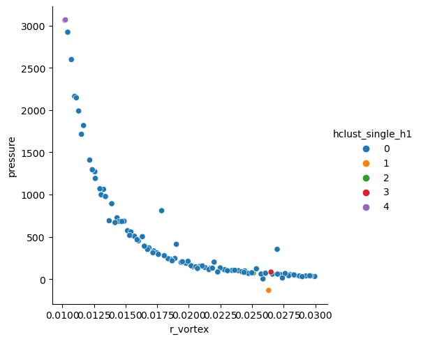

```python
sns.relplot(data = netl_copy, x='r_vortex', y='pressure', hue='hclust_single_h1')

plt.show()
```

```python
netl_copy.loc[ netl_copy.hclust_single_h1 == 2, :]
```

|  | model | r_barrel | r_vortex | h_vortex | w_inlet | h_inlet | mass | pressure | k2_qt | hclust_single_h1 |
| --- | --- | --- | --- | --- | --- | --- | --- | --- | --- | --- |
| 24 | 24 | 0.087015 | 0.025104 | 0.310189 | 0.035309 | 0.075721 | 3.600000e-10 | 70.624062 | 0 | 2 |

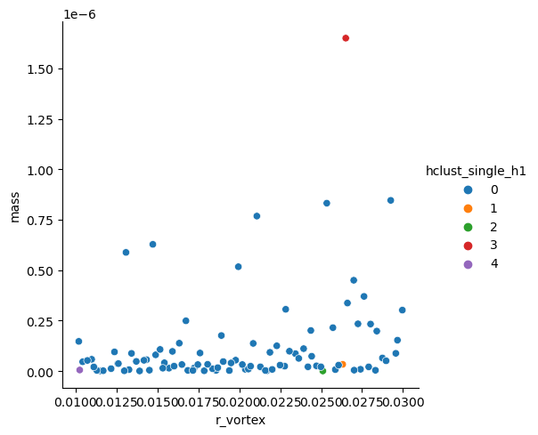

```python
sns.relplot(data = netl_copy, x='r_vortex', y='mass', hue='hclust_single_h1')

plt.show()
```